# Session 4: Time Series in R

From ordered observations to forecasts

Oscar Rodriguez de Rivera | University of Exeter

# 1 Session overview

## 1.1 Where this session fits

In the previous sessions we moved from:

- **data representation**, where we learned how to describe and visualise data;
- **GLMs and GLMMs**, where we modelled non-normal responses and grouped data;
- **multivariate methods**, where we looked at patterns across several variables at once.

This session adds another common feature of environmental and ecological data: **time**.

Many environmental datasets are not just collections of independent observations. They are ordered through time. For example:

- monthly atmospheric CO2 concentrations;
- annual species abundance;
- daily temperature;
- weekly disease incidence;
- seasonal fire counts;
- long-term biodiversity monitoring data.

When observations are ordered in time, nearby observations are often more similar to each other than observations far apart in time. This creates **temporal dependence**.

Time-series thinking helps us recognise:

- trends;
- seasonality;
- autocorrelation;
- changes in variability;
- structured residuals;
- possible forecasting patterns.

This is important before moving to flexible models such as GAMs, because GAMs can model nonlinear temporal trends but do not automatically solve all time-series issues.

## 1.2 Learning outcomes

By the end of this document, students should be able to:

1. recognise trend, seasonality and residual variation in a time series;
2. explain why time ordering matters;
3. compute and interpret autocorrelation plots;
4. decompose a seasonal time series;
5. fit simple smoothing and ARIMA-style models;
6. produce simple forecasts;
7. connect time-series thinking to later GAM modelling.

# 2 Setup

## 2.1 Packages

This document uses base R time-series functions plus `tidyverse` for plotting. Optional forecasting examples use base `stats` functions, so the examples do not depend on external data files.

```r
install.packages("tidyverse")
```

```r
library(tidyverse)

theme_set(theme_minimal(base_size = 12))
```

# 3 What is a time series?

## 3.1 Ordered observations

A time series is a set of observations ordered through time.

The order matters. If we randomly shuffle the observations, we destroy important information.

For example, in a time series we might observe:

$$Y_1, Y_2, Y_3, \ldots, Y_t$$

where (t) indexes time.

The value at time (t) may depend on previous values, such as (Y_{t-1}) or (Y_{t-2}). This is one reason why ordinary regression assumptions may fail.

## 3.2 Common features of time series

Time series often contain several components:

| Component | Meaning |
| --- | --- |
| Trend | Long-term increase or decrease |
| Seasonality | Repeating pattern at regular intervals |
| Cycles | Longer-term rises and falls, not always fixed in period |
| Autocorrelation | Correlation between observations at different time lags |
| Noise | Short-term unexplained variation |

In environmental data, these components often occur together.

For example, atmospheric CO2 has a long-term increasing trend and a repeated annual seasonal cycle.

# 4 A first time series: atmospheric CO2

## 4.1 The `co2` dataset

We use the built-in `co2` dataset. It contains monthly atmospheric carbon dioxide concentrations from Mauna Loa.

The object `co2` is already stored as a base R time-series object.

```r
co2
```

```
##         Jan    Feb    Mar    Apr    May    Jun    Jul    Aug    Sep    Oct
## 1959 315.42 316.31 316.50 317.56 318.13 318.00 316.39 314.65 313.68 313.18
## 1960 316.27 316.81 317.42 318.87 319.87 319.43 318.01 315.74 314.00 313.68
## 1961 316.73 317.54 318.38 319.31 320.42 319.61 318.42 316.63 314.83 315.16
## 1962 317.78 318.40 319.53 320.42 320.85 320.45 319.45 317.25 316.11 315.27
## 1963 318.58 318.92 319.70 321.22 322.08 321.31 319.58 317.61 316.05 315.83
## 1964 319.41 320.07 320.74 321.40 322.06 321.73 320.27 318.54 316.54 316.71
## 1965 319.27 320.28 320.73 321.97 322.00 321.71 321.05 318.71 317.66 317.14
## 1966 320.46 321.43 322.23 323.54 323.91 323.59 322.24 320.20 318.48 317.94
## 1967 322.17 322.34 322.88 324.25 324.83 323.93 322.38 320.76 319.10 319.24
## 1968 322.40 322.99 323.73 324.86 325.40 325.20 323.98 321.95 320.18 320.09
## 1969 323.83 324.26 325.47 326.50 327.21 326.54 325.72 323.50 322.22 321.62
## 1970 324.89 325.82 326.77 327.97 327.91 327.50 326.18 324.53 322.93 322.90
## 1971 326.01 326.51 327.01 327.62 328.76 328.40 327.20 325.27 323.20 323.40
## 1972 326.60 327.47 327.58 329.56 329.90 328.92 327.88 326.16 324.68 325.04
```

[output cut: 65 more lines]

```r
start(co2)
```

```
## [1] 1959    1
```

```r
end(co2)
```

```
## [1] 1997   12
```

```r
frequency(co2)
```

```
## [1] 12
```

The frequency is 12 because the data are monthly.

## 4.2 Convert to a tibble for plotting

It is often useful to convert a time-series object into a tidy data frame for plotting with `ggplot2`.

```r
co2_ts <- datasets::co2

co2_tbl <- tibble(
  year = as.numeric(time(co2_ts)),
  month_num = as.integer(cycle(co2_ts)),
  month = factor(month_num, levels = 1:12, labels = month.abb),
  co2 = as.numeric(co2_ts)
)

glimpse(co2_tbl)
```

```
## Rows: 468
## Columns: 4
## $ year      <dbl> 1959.000, 1959.083, 1959.167, 1959.250, 1959.333, 1959.417, …
## $ month_num <int> 1, 2, 3, 4, 5, 6, 7, 8, 9, 10, 11, 12, 1, 2, 3, 4, 5, 6, 7, …
## $ month     <fct> Jan, Feb, Mar, Apr, May, Jun, Jul, Aug, Sep, Oct, Nov, Dec, …
## $ co2       <dbl> 315.42, 316.31, 316.50, 317.56, 318.13, 318.00, 316.39, 314.…
```

## 4.3 Plot the raw series

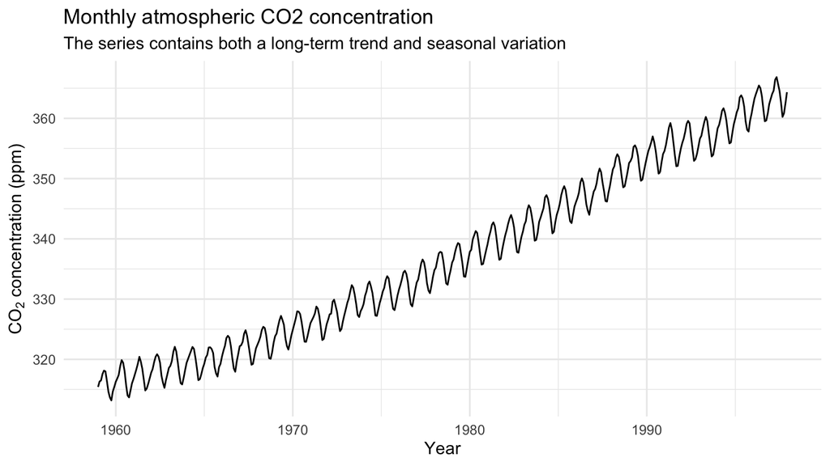

```r
ggplot(co2_tbl, aes(x = year, y = co2)) +
  geom_line() +
  labs(
    x = "Year",
    y = expression(CO[2]~"concentration (ppm)"),
    title = "Monthly atmospheric CO2 concentration",
    subtitle = "The series contains both a long-term trend and seasonal variation"
  )
```

## 4.4 Interpreting the plot

The plot contains two strong features.

First, there is a long-term upward **trend**. CO2 concentration increases through time.

Second, there is a repeating annual **seasonal cycle**. Within each year, CO2 rises and falls in a regular pattern.

These two features are superimposed. The observed value at any time is influenced by both the long-term trend and the seasonal cycle.

# 5 Seasonal patterns

## 5.1 Why look at months?

A simple way to see seasonality is to compare observations by month.

This asks:

> Are values systematically higher or lower in some months?

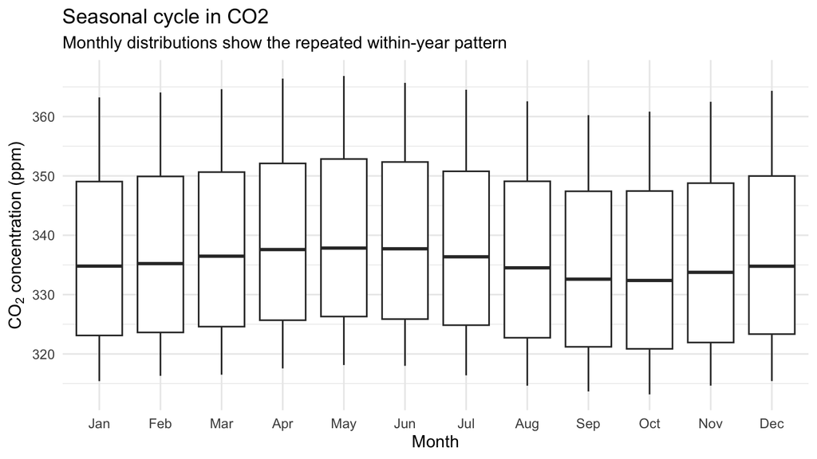

```r
ggplot(co2_tbl, aes(x = month, y = co2)) +
  geom_boxplot() +
  labs(
    x = "Month",
    y = expression(CO[2]~"concentration (ppm)"),
    title = "Seasonal cycle in CO2",
    subtitle = "Monthly distributions show the repeated within-year pattern"
  )
```

## 5.2 Interpreting the seasonal plot

This plot makes the within-year cycle visible.

However, it does not remove the long-term trend. Because CO2 increases over time, later years contribute higher values to every month.

This means the boxplots show both:

- differences among months;
- the long-term increase across years.

For a clearer separation of trend and seasonality, we can use decomposition.

# 6 Decomposing a time series

## 6.1 Trend, seasonality and remainder

Classical decomposition separates the series into:

$$Y_t = T_t + S_t + R_t$$

where:

- (Y_t) is the observed value;
- (T_t) is the trend component;
- (S_t) is the seasonal component;
- (R_t) is the remainder or residual component.

This is an **additive decomposition**. It is appropriate when the size of the seasonal pattern is roughly constant through time.

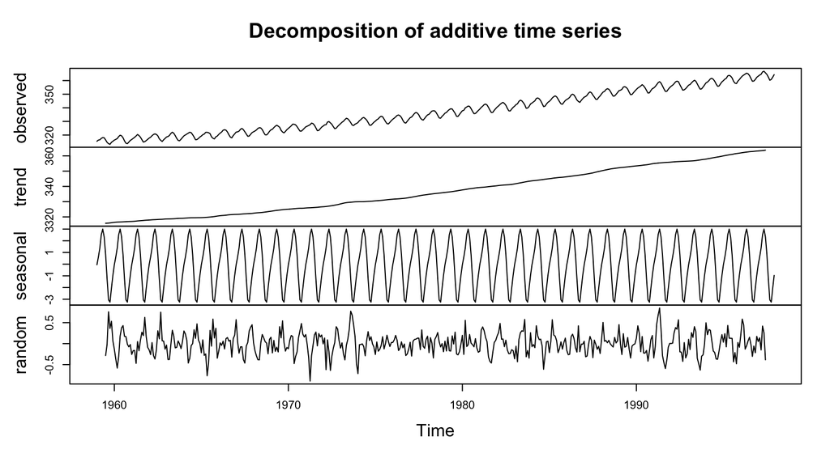

```r
co2_decomp <- decompose(co2_ts)

plot(co2_decomp)
```

## 6.2 Interpreting the decomposition

The decomposition plot shows four panels:

1. the observed series;
2. the estimated trend;
3. the estimated seasonal component;
4. the remainder after removing trend and seasonality.

The trend panel shows the long-term increase.

The seasonal panel shows the repeating annual pattern.

The remainder panel shows what is left after removing the estimated trend and seasonal cycle.

If the remainder still has strong patterns, this suggests that the decomposition has not captured all the structure.

# 7 Seasonal adjustment

## 7.1 Remove the seasonal component

A seasonally adjusted series removes the estimated seasonal component.

This is useful when we want to focus on the long-term trend without the repeating seasonal cycle.

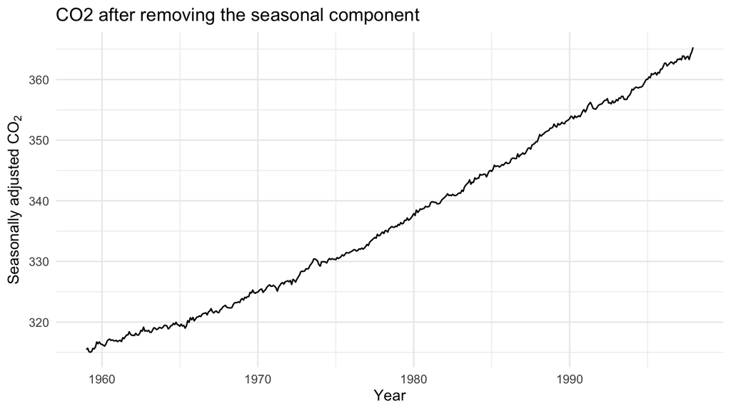

```r
co2_adjusted <- co2_ts - co2_decomp$seasonal

adjusted_tbl <- tibble(
  year = as.numeric(time(co2_adjusted)),
  co2_adjusted = as.numeric(co2_adjusted)
)

ggplot(adjusted_tbl, aes(x = year, y = co2_adjusted)) +
  geom_line() +
  labs(
    x = "Year",
    y = expression("Seasonally adjusted "*CO[2]),
    title = "CO2 after removing the seasonal component"
  )
```

## 7.2 Interpretation

The seasonally adjusted series makes the long-term trend easier to see.

However, seasonal adjustment is not the same as fitting a full statistical model. It is mainly an exploratory step.

Later, GAMs allow us to model smooth temporal patterns more flexibly.

# 8 Autocorrelation

## 8.1 What is autocorrelation?

Time-series observations are often not independent.

Autocorrelation means that values close together in time are correlated.

For example, if this month’s CO2 concentration is high, next month’s value is also likely to be high.

The autocorrelation function, or **ACF**, shows correlation between observations separated by different lags.

A lag of 1 means one time step apart. For monthly data, lag 1 means one month apart. Lag 12 means one year apart.

## 8.2 ACF and PACF

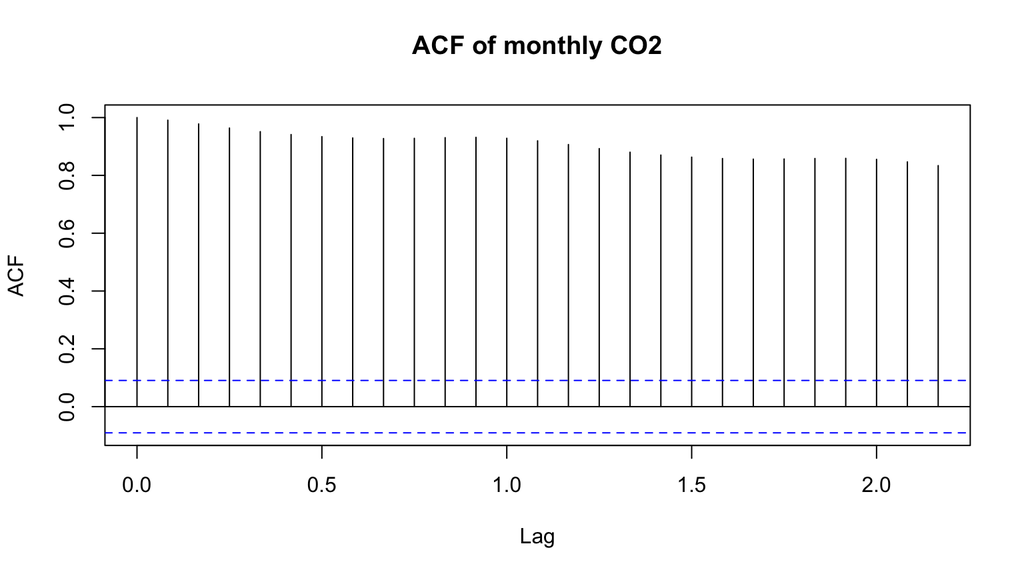

```r
acf(co2_ts, main = "ACF of monthly CO2")
```

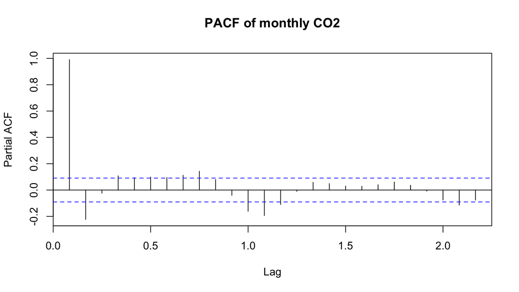

```r
pacf(co2_ts, main = "PACF of monthly CO2")
```

## 8.3 Interpreting the ACF

The ACF shows strong autocorrelation.

This is expected because the series has a strong trend and seasonal cycle.

In ordinary linear models and GLMs, we often assume independent residuals. Time-series data frequently violate this assumption.

A useful workflow is:

1. plot the raw series;
2. identify trend and seasonality;
3. decompose or model those structures;
4. inspect whether residuals still show autocorrelation.

# 9 Smoothing with moving averages

## 9.1 Moving averages

Moving averages are simple descriptive smoothers.

They replace each observation with an average of nearby observations. This reduces short-term fluctuations and helps reveal the underlying trend.

Here we use the built-in `AirPassengers` dataset, which records monthly airline passenger totals.

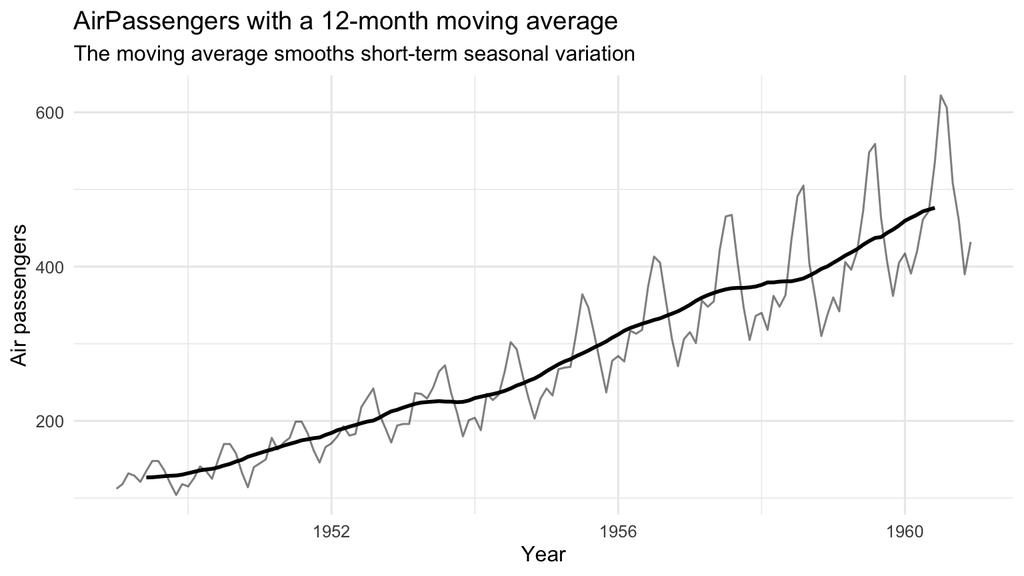

```r
air_ts <- datasets::AirPassengers

air_tbl <- tibble(
  year = as.numeric(time(air_ts)),
  passengers = as.numeric(air_ts),
  moving_average = as.numeric(stats::filter(air_ts, rep(1 / 12, 12), sides = 2))
)

ggplot(air_tbl, aes(x = year)) +
  geom_line(aes(y = passengers), alpha = 0.5) +
  geom_line(aes(y = moving_average), linewidth = 1) +
  labs(
    x = "Year",
    y = "Air passengers",
    title = "AirPassengers with a 12-month moving average",
    subtitle = "The moving average smooths short-term seasonal variation"
  )
```

## 9.2 Interpretation

The raw series shows both growth and seasonality.

The 12-month moving average smooths over the annual cycle, making the long-term increase easier to see.

Moving averages are exploratory. They do not provide a full probability model, but they are useful for understanding the structure of the data.

# 10 Exponential smoothing

## 10.1 Holt-Winters smoothing

The `HoltWinters()` function fits exponential smoothing models.

Exponential smoothing gives more weight to recent observations and less weight to older observations.

It can handle level, trend and seasonality.

Here we use it to forecast future CO2 values.

```r
hw_fit <- HoltWinters(co2_ts)

hw_pred <- predict(
  hw_fit,
  n.ahead = 24,
  prediction.interval = TRUE
)

hw_tbl <- as.data.frame(hw_pred) %>%
  tibble::rownames_to_column("time_index") %>%
  dplyr::mutate(
    year = as.numeric(time(hw_pred))
  )

head(hw_tbl)
```

|  | time_index | fit | upr | lwr | year |
| --- | --- | --- | --- | --- | --- |
| 1 | 1 | 365.1079 | 365.7105 | 364.5053 | 1998.000 |
| 2 | 2 | 365.9664 | 366.6449 | 365.2879 | 1998.083 |
| 3 | 3 | 366.7343 | 367.4823 | 365.9864 | 1998.167 |
| 4 | 4 | 368.1364 | 368.9490 | 367.3238 | 1998.250 |
| 5 | 5 | 368.6674 | 369.5410 | 367.7937 | 1998.333 |
| 6 | 6 | 367.9508 | 368.8824 | 367.0192 | 1998.417 |

## 10.2 Plot Holt-Winters forecast

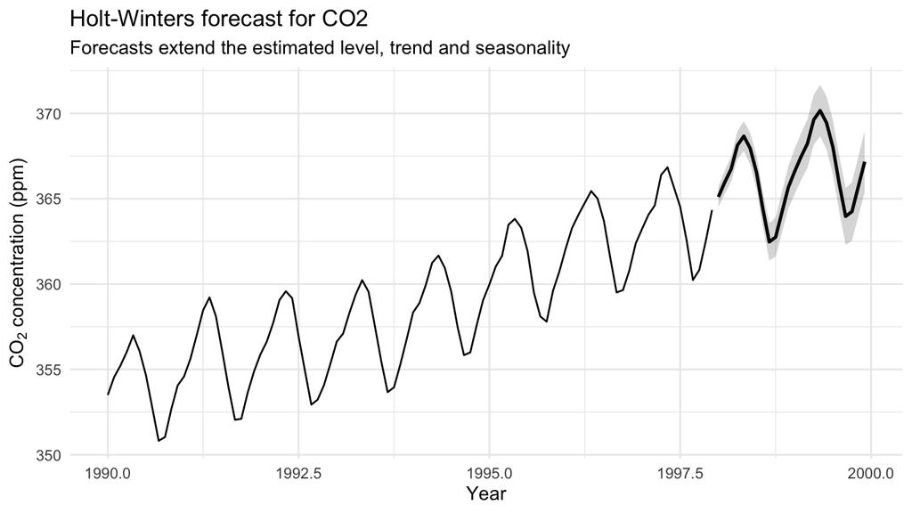

```r
co2_recent <- co2_tbl %>%
  dplyr::filter(year >= 1990)

forecast_tbl <- hw_tbl %>%
  dplyr::rename(
    forecast = fit,
    lower = lwr,
    upper = upr
  )

ggplot() +
  geom_line(data = co2_recent, aes(x = year, y = co2)) +
  geom_line(data = forecast_tbl, aes(x = year, y = forecast), linewidth = 1) +
  geom_ribbon(
    data = forecast_tbl,
    aes(x = year, ymin = lower, ymax = upper),
    alpha = 0.2
  ) +
  labs(
    x = "Year",
    y = expression(CO[2]~"concentration (ppm)"),
    title = "Holt-Winters forecast for CO2",
    subtitle = "Forecasts extend the estimated level, trend and seasonality"
  )
```

## 10.3 Interpreting the forecast

The forecast continues the recent trend and seasonal cycle.

The shaded interval represents uncertainty. The interval widens further into the future because forecasts become more uncertain as the prediction horizon increases.

Forecasts are not guaranteed predictions of what will happen. They are projections based on the structure estimated from the historical data.

# 11 ARIMA-style modelling

## 11.1 What is ARIMA?

ARIMA models are a common class of time-series models.

ARIMA stands for:

- **AR**: autoregressive terms;
- **I**: integrated, meaning differencing to remove trend;
- **MA**: moving-average terms.

An ARIMA model tries to describe temporal dependence in the series.

For seasonal data, we can include seasonal ARIMA components.

## 11.2 Log-transform AirPassengers

The `AirPassengers` series has increasing variability through time. A log transformation helps stabilise the variance.

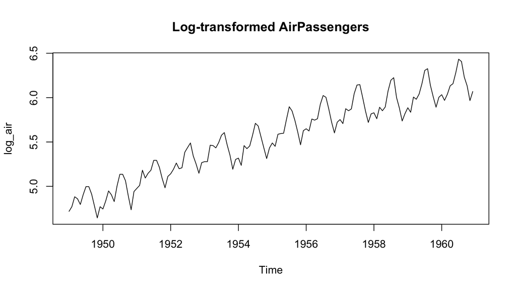

```r
log_air <- log(air_ts)

plot(log_air, main = "Log-transformed AirPassengers")
```

## 11.3 Fit a simple seasonal ARIMA model

```r
arima_fit <- arima(
  log_air,
  order = c(0, 1, 1),
  seasonal = list(order = c(0, 1, 1), period = 12)
)

arima_fit
```

```
##
## Call:
## arima(x = log_air, order = c(0, 1, 1), seasonal = list(order = c(0, 1, 1), period = 12))
##
## Coefficients:
##           ma1     sma1
##       -0.4018  -0.5569
## s.e.   0.0896   0.0731
##
## sigma^2 estimated as 0.001348:  log likelihood = 244.7,  aic = -483.4
```

This model uses:

- first differencing to remove the long-term trend;
- seasonal differencing to remove annual seasonality;
- moving-average terms for short-term and seasonal dependence.

This is a simple teaching example rather than a full model selection workflow.

## 11.4 Check residual autocorrelation

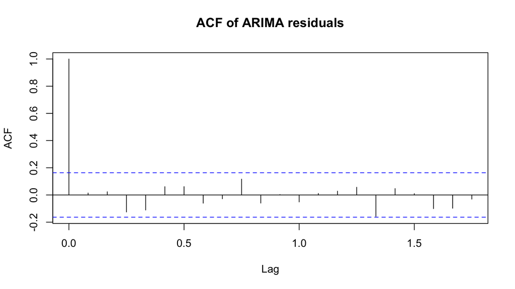

```r
acf(residuals(arima_fit), main = "ACF of ARIMA residuals")
```

## 11.5 Interpretation

After fitting a time-series model, we inspect the residuals.

If the model has captured the main temporal structure, the residual autocorrelation should be much weaker.

If strong autocorrelation remains, the model may be missing important structure.

# 12 ARIMA forecast

## 12.1 Forecast future values

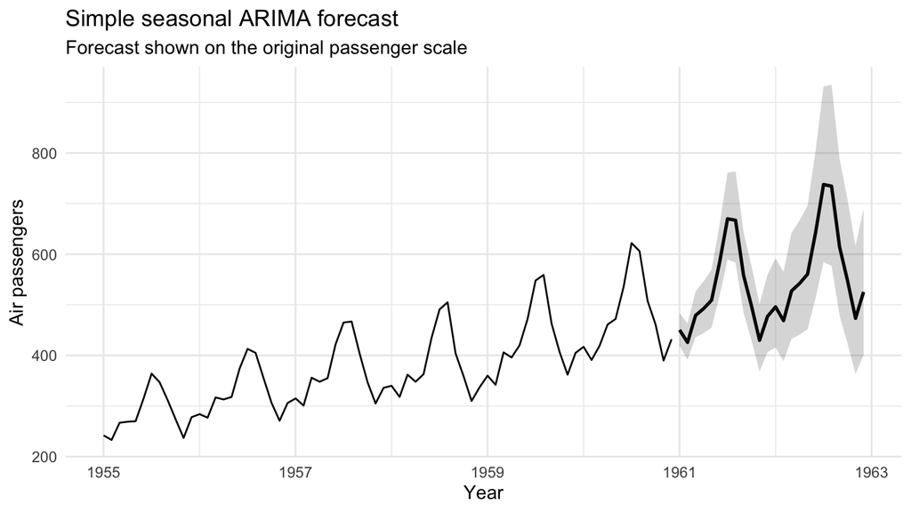

```r
arima_pred <- predict(arima_fit, n.ahead = 24)

future_time <- seq(
  from = max(as.numeric(time(air_ts))) + 1 / 12,
  by = 1 / 12,
  length.out = 24
)

arima_forecast_tbl <- tibble(
  year = future_time,
  forecast = exp(arima_pred$pred),
  lower = exp(arima_pred$pred - 1.96 * arima_pred$se),
  upper = exp(arima_pred$pred + 1.96 * arima_pred$se)
)

air_recent <- air_tbl %>%
  dplyr::filter(year >= 1955)

ggplot() +
  geom_line(data = air_recent, aes(x = year, y = passengers)) +
  geom_line(data = arima_forecast_tbl, aes(x = year, y = forecast), linewidth = 1) +
  geom_ribbon(
    data = arima_forecast_tbl,
    aes(x = year, ymin = lower, ymax = upper),
    alpha = 0.2
  ) +
  labs(
    x = "Year",
    y = "Air passengers",
    title = "Simple seasonal ARIMA forecast",
    subtitle = "Forecast shown on the original passenger scale"
  )
```

## 12.2 Interpretation

The model was fitted on the log scale, so the forecasts are transformed back using `exp()`.

This gives forecasts on the original passenger scale.

The forecast keeps both the long-term pattern and the seasonal cycle.

# 13 Connection to GAMs

## 13.1 Time-series models versus GAMs

Time-series models focus on temporal dependence.

GAMs focus on flexible relationships between predictors and responses.

For example, a GAM can model a smooth nonlinear trend through time:

```r
mgcv::gam(
  response ~ s(time),
  data = my_data
)
```

However, a smooth temporal trend does not automatically handle autocorrelation. If residuals are temporally correlated, we may need additional structure.

This is why time-series exploration is useful before fitting GAMs.

A practical workflow is:

1. plot the time series;
2. identify trend and seasonality;
3. check autocorrelation;
4. fit an appropriate model;
5. check residuals;
6. interpret predictions carefully.

# 14 Exercise

## 14.1 Exercise: explore a built-in time series

Using either `co2`, `AirPassengers` or another built-in time series such as `nottem`:

1. plot the raw series;
2. check whether seasonality is visible;
3. plot the ACF;
4. decompose the series if it has a seasonal frequency;
5. describe whether the residual component still looks structured.

# 15 Exercise solution

## 15.1 Use the `nottem` dataset

The `nottem` dataset contains average monthly air temperatures at Nottingham Castle.

```r
nottem_ts <- datasets::nottem

nottem_tbl <- tibble(
  year = as.numeric(time(nottem_ts)),
  month_num = as.integer(cycle(nottem_ts)),
  month = factor(month_num, levels = 1:12, labels = month.abb),
  temperature = as.numeric(nottem_ts)
)

glimpse(nottem_tbl)
```

```
## Rows: 240
## Columns: 4
## $ year        <dbl> 1920.000, 1920.083, 1920.167, 1920.250, 1920.333, 1920.417…
## $ month_num   <int> 1, 2, 3, 4, 5, 6, 7, 8, 9, 10, 11, 12, 1, 2, 3, 4, 5, 6, 7…
## $ month       <fct> Jan, Feb, Mar, Apr, May, Jun, Jul, Aug, Sep, Oct, Nov, Dec…
## $ temperature <dbl> 40.6, 40.8, 44.4, 46.7, 54.1, 58.5, 57.7, 56.4, 54.3, 50.5…
```

## 15.2 1. Plot the raw series

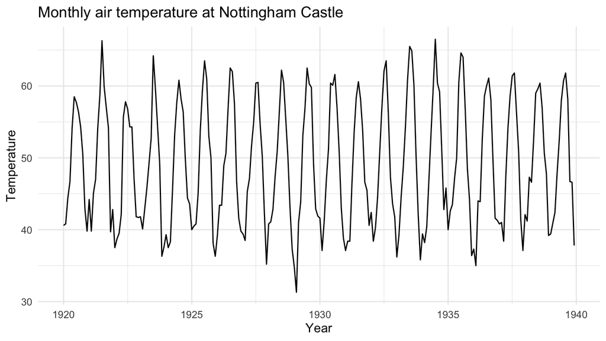

```r
ggplot(nottem_tbl, aes(x = year, y = temperature)) +
  geom_line() +
  labs(
    title = "Monthly air temperature at Nottingham Castle",
    x = "Year",
    y = "Temperature"
  )
```

The raw series shows strong repeated seasonal variation. Temperatures rise and fall every year.

## 15.3 2. Check whether seasonality is visible

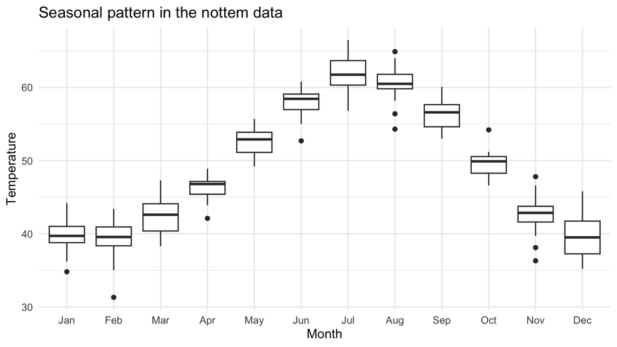

```r
ggplot(nottem_tbl, aes(x = month, y = temperature)) +
  geom_boxplot() +
  labs(
    title = "Seasonal pattern in the nottem data",
    x = "Month",
    y = "Temperature"
  )
```

The monthly boxplots show a clear seasonal pattern. Temperatures are generally higher in summer months and lower in winter months.

## 15.4 3. Plot the ACF

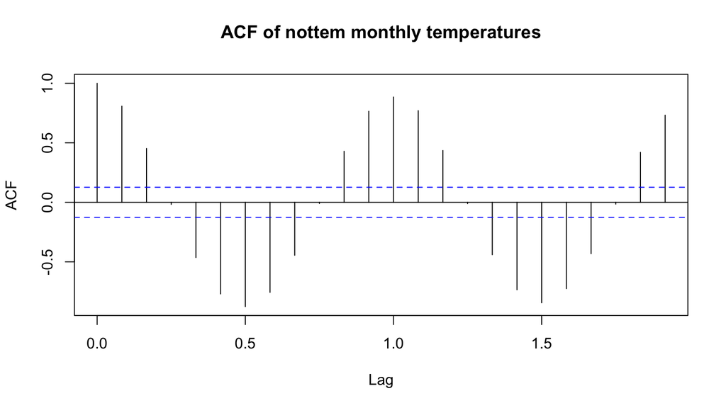

```r
acf(nottem_ts, main = "ACF of nottem monthly temperatures")
```

## 15.5 4. Decompose the series

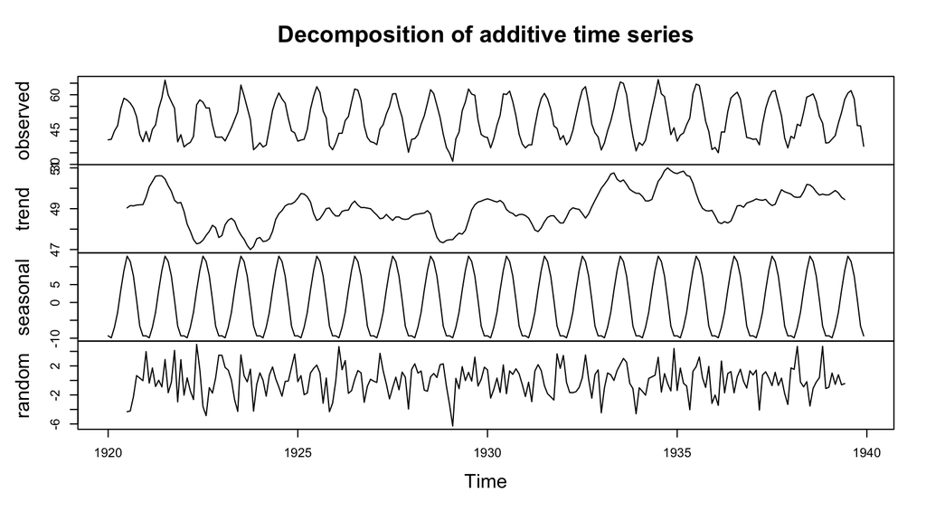

```r
nottem_decomp <- decompose(nottem_ts)

plot(nottem_decomp)
```

The decomposition separates the observed series into trend, seasonal and random components.

The seasonal component is strong and repeated.

## 15.6 5. Inspect the residual component

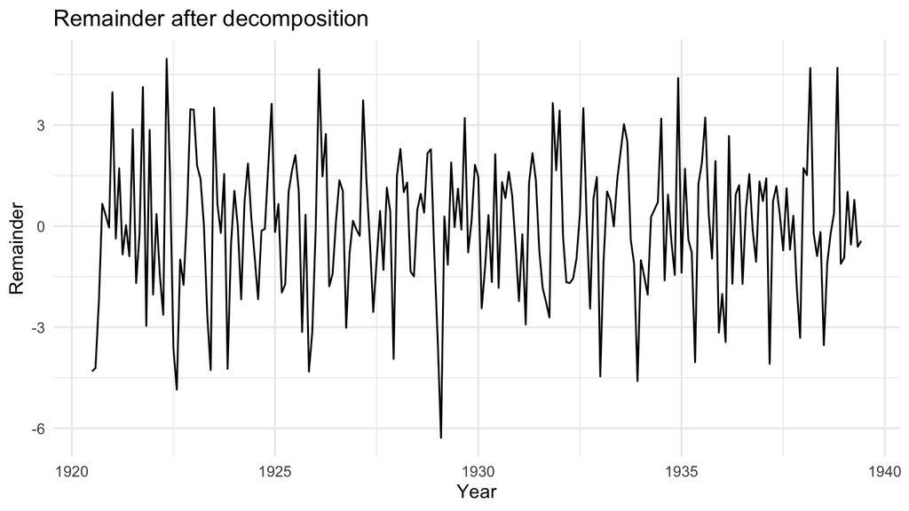

```r
nottem_remainder_tbl <- tibble(
  year = as.numeric(time(nottem_decomp$random)),
  remainder = as.numeric(nottem_decomp$random)
) %>%
  tidyr::drop_na()

ggplot(nottem_remainder_tbl, aes(x = year, y = remainder)) +
  geom_line() +
  labs(
    title = "Remainder after decomposition",
    x = "Year",
    y = "Remainder"
  )
```

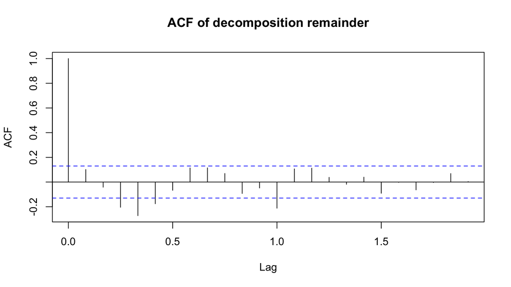

```r
acf(
  na.omit(nottem_decomp$random),
  main = "ACF of decomposition remainder"
)
```

## 15.7 Exercise interpretation

The `nottem` data show strong seasonality, with clear repeated annual temperature cycles.

The decomposition captures much of this seasonal structure.

If the remainder still shows visible patterns or autocorrelation, this suggests that the simple decomposition has not captured all temporal dependence. In that case, a more formal time-series model or a GAM with seasonal and temporal smooths might be useful.

# 16 Summary

In this session, we introduced basic time-series thinking in R.

Key points:

- time-series observations are ordered;
- nearby observations are often autocorrelated;
- many environmental time series contain trend and seasonality;
- decomposition separates trend, seasonality and remainder;
- moving averages are useful exploratory smoothers;
- Holt-Winters models can forecast level, trend and seasonality;
- ARIMA models describe temporal dependence through differencing, autoregressive and moving-average terms;
- residual autocorrelation is important for model checking;
- time-series exploration is a useful bridge to GAMs.

# 17 Link to the next document

Time-series models are useful when the main structure is temporal dependence.

GAMs take a different approach. They model nonlinear relationships using smooth functions.

In the next document, we use GAMs to model nonlinear environmental trends and flexible smooth relationships.